# Master_Юлия Шаталина_review (1)

### Таблица apparel

```python
data_apparel = pd.read_csv('F:\Data\data\\apparel-purchases.csv')
```

```python
data_apparel.head()
```

|  | client_id | quantity | price | date | message_id | recommended_by |
| --- | --- | --- | --- | --- | --- | --- |
| 0 | 1515915625468068833 | 1 | 3499.0 | 2023-09-08 | 1515915625468068833-13781-64fad81bece56 | bulk_message |
| 1 | 1515915625468068833 | 1 | 3499.0 | 2023-09-08 | 1515915625468068833-13781-64fad81bece56 | bulk_message |
| 2 | 1515915625468068833 | 1 | 3499.0 | 2023-09-08 | 1515915625468068833-13781-64fad81bece56 | bulk_message |
| 3 | 1515915625468068833 | 1 | 2450.0 | 2023-09-08 | 1515915625468068833-13781-64fad81bece56 | bulk_message |
| 4 | 1515915625468068833 | 1 | 2450.0 | 2023-09-08 | 1515915625468068833-13781-64fad81bece56 | bulk_message |

Так же удаляем ненужные столбцы

```python
df_apparel = data_apparel.drop(columns=['message_id','recommended_by'])
```

```python
df_apparel.info()
```

```
<class 'pandas.core.frame.DataFrame'>
RangeIndex: 133104 entries, 0 to 133103
Data columns (total 4 columns):
 #   Column     Non-Null Count   Dtype
---  ------     --------------   -----
 0   client_id  133104 non-null  int64
 1   quantity   133104 non-null  int64
 2   price      133104 non-null  float64
 3   date       133104 non-null  object
dtypes: float64(1), int64(2), object(1)
memory usage: 4.1+ MB
```

Делаем тот же набор операций, что и с прошлой таблицей.

```python
df_apparel['date'] = pd.to_datetime(df_apparel['date'])
```

```python
df_apparel.duplicated().sum()
```

```
59279
```

```python
df_apparel[df_apparel.duplicated()].sort_values('client_id').head(10)
```

|  | client_id | quantity | price | date |
| --- | --- | --- | --- | --- |
| 4144 | 1515915625468061003 | 1 | 2100.0 | 2023-01-04 |
| 7680 | 1515915625468061170 | 1 | 2195.0 | 2023-03-29 |
| 7681 | 1515915625468061170 | 1 | 2199.0 | 2023-03-29 |
| 7672 | 1515915625468061170 | 1 | 7.0 | 2023-03-26 |
| 7674 | 1515915625468061170 | 1 | 2699.0 | 2023-03-26 |
| 7676 | 1515915625468061170 | 1 | 2199.0 | 2023-03-29 |
| 13659 | 1515915625468061170 | 1 | 999.0 | 2023-06-17 |
| 7678 | 1515915625468061170 | 1 | 1609.0 | 2023-03-29 |
| 13658 | 1515915625468061170 | 1 | 999.0 | 2023-06-17 |
| 7682 | 1515915625468061170 | 1 | 2199.0 | 2023-03-29 |

```python
df_apparel.isna().sum()
```

```
client_id    0
quantity     0
price        0
date         0
dtype: int64
```

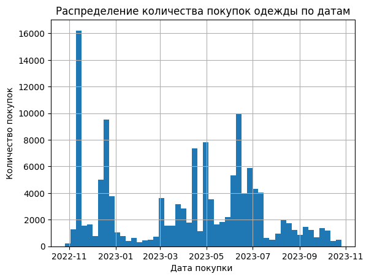

```python
df_apparel['date'].hist(bins=50)

plt.xlabel("Дата покупки ")
plt.ylabel("Количество покупок")
plt.title('Распределение количества покупок одежды по датам')
plt.show()
```

Можно отметить пик покупок в ноябре - вероятно связано с распродажами 11.11, пики перед празниками и летом - в сезон смены одежды

```python
df_apparel['date'].max()
```

```
Timestamp('2023-10-26 00:00:00')
```

```python
df_apparel['date'].min()
```

```
Timestamp('2022-10-26 00:00:00')
```

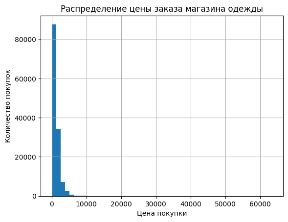

```python
df_apparel['price'].hist(bins=50)

plt.xlabel("Цена покупки")
plt.ylabel("Количество покупок")
plt.title('Распределение цены заказа магазина одежды')
plt.show()
```

```
{'whiskers': [<matplotlib.lines.Line2D at 0x21b90386950>,
 'caps': [<matplotlib.lines.Line2D at 0x21b903858a0>,
 'boxes': [<matplotlib.lines.Line2D at 0x21b90385390>],
 'medians': [<matplotlib.lines.Line2D at 0x21b901d9570>],
 'fliers': [<matplotlib.lines.Line2D at 0x21b901d9b70>],
 'means': []}
```

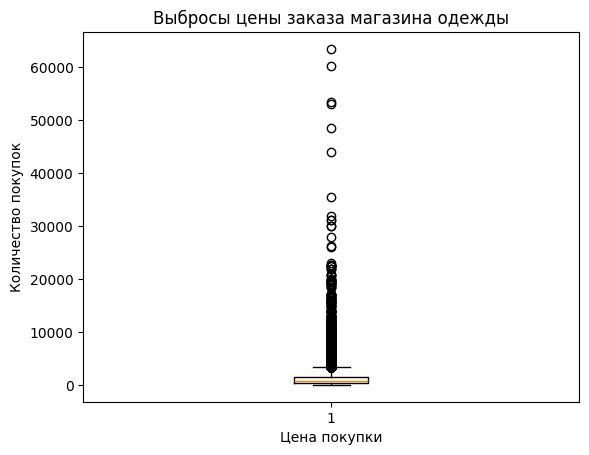

```python
fig = plt.figure()
ax = fig.add_subplot(111)

plt.xlabel("Цена покупки")
plt.ylabel("Количество покупок")
plt.title('Выбросы цены заказа магазина одежды')
ax.boxplot(df_apparel['price'])
```

```
{'whiskers': [<matplotlib.lines.Line2D at 0x21b8e62e260>,
 'caps': [<matplotlib.lines.Line2D at 0x21b8da06f20>,
 'boxes': [<matplotlib.lines.Line2D at 0x21b9017bfd0>],
 'medians': [<matplotlib.lines.Line2D at 0x21b903a8be0>],
 'fliers': [<matplotlib.lines.Line2D at 0x21b903a8e80>],
 'means': []}
```

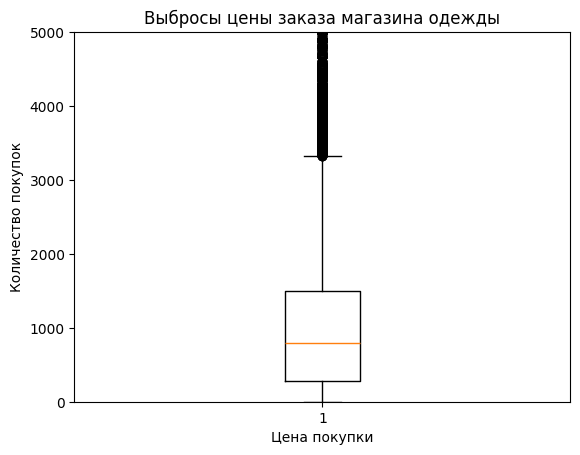

```python
fig = plt.figure()
ax = fig.add_subplot(111)
ax.set_ylim(0, 5000)
plt.xlabel("Цена покупки")
plt.ylabel("Количество покупок")
plt.title('Выбросы цены заказа магазина одежды')
ax.boxplot(df_apparel['price'])
```

Основная часть заказов стоит до 1000 рублей, самый дорогой заказ стоит свыше 60 000 рублей

```python
df_apparel['price'].describe()
```

```
count    133104.000000
mean       1110.433067
std        1257.080854
min           1.000000
25%         280.000000
50%         799.000000
75%        1499.000000
max       63499.000000
Name: price, dtype: float64
```

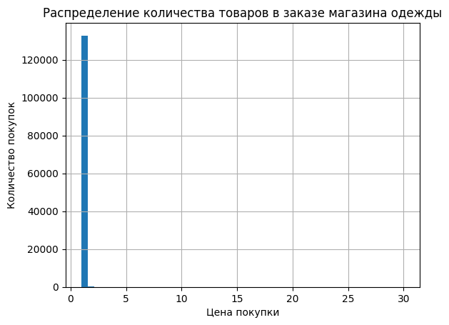

```python
df_apparel['quantity'].hist(bins=50)

plt.xlabel("Цена покупки")
plt.ylabel("Количество покупок")
plt.title('Распределение количества товаров в заказе магазина одежды')
plt.show()
```

Количество покупок в заказе чаще всего - 1.

```python
df_apparel['quantity'].describe()
```

```
count    133104.000000
mean          1.004312
std           0.149315
min           1.000000
25%           1.000000
50%           1.000000
75%           1.000000
max          30.000000
Name: quantity, dtype: float64
```

Выводы по таблице apparel_purchases:

- Дана таблица на 133104 строк без пропусков
- Есть 59279 строк дубликатов, часть из них не 100%
- Данные даны за год с 26.10.2022 по 26.10.2023 года
- Удалили столбцы message_id, recommended_by
- Дубликаты не стали удалять
- В основном товары куплены в количестве 1 штука
- Стоимость покупки составляет в среднем 1110 рублей
- Большая часть покупок стоит до 1500 рублей, основная - до 1000 рублей
- Минимальная цена покупки - 1 рубль, максимальная свыше 60 тысяч рублей
- Можно отметить пик покупок в ноябре - вероятно связано с распродажами 11.11, пики перед празниками и летом - в сезон смены одежды